# Unsupervised Clustering - Case

## Problem

ScooterX is a manufacturer of scooters. They regular collect user ratings on the usability, safety, and affordability of their scooters. Additionally, they collect a general rating from users and the collect the heights of users. They would like to understand how to segment out their customers and have provided you their rating data to work with. Currently, there are no classifications present.

In this case, we will learn how to apply K-means clustering and hiearchical clustering to identify classes.

## Step 1: Import Modules

```python
import numpy as np
import pandas as pd
import matplotlib.pyplot as plt
from sklearn.cluster import KMeans
import seaborn as sns
%matplotlib inline
```

## Step 2: Read in Data

```python
df = pd.read_csv("data/ratings.csv", index_col = 0)
df.head()
```

|  | Usability Rating | Safety Rating | Affordability Rating | General Rating | Height |
| --- | --- | --- | --- | --- | --- |
| 0 | 1.111111 | 3.125000 | 0.338983 | 0.208333 | 168 |
| 1 | 0.833333 | 2.083333 | 0.338983 | 0.208333 | 190 |
| 2 | 0.555556 | 2.500000 | 0.254237 | 0.208333 | 209 |
| 3 | 0.416667 | 2.291667 | 0.423729 | 0.208333 | 194 |
| 4 | 0.972222 | 3.333333 | 0.338983 | 0.208333 | 182 |

## Step 3: Convert into Features Matrix

```python
X = df.iloc[:, [0,1,2,3,4]].values # get the five columns as an array
X
```

```
array([[  1.11111111e+00,   3.12500000e+00,   3.38983051e-01,
          2.08333333e-01,   1.68000000e+02],
       [  8.33333333e-01,   2.08333333e+00,   3.38983051e-01,
          2.08333333e-01,   1.90000000e+02],
       [  5.55555556e-01,   2.50000000e+00,   2.54237288e-01,
          2.08333333e-01,   2.09000000e+02],
       [  4.16666667e-01,   2.29166667e+00,   4.23728814e-01,
          2.08333333e-01,   1.94000000e+02],
       [  9.72222222e-01,   3.33333333e+00,   3.38983051e-01,
          2.08333333e-01,   1.82000000e+02],
       [  1.52777778e+00,   3.95833333e+00,   5.93220339e-01,
          6.25000000e-01,   1.85000000e+02],
       [  4.16666667e-01,   2.91666667e+00,   3.38983051e-01,
          4.16666667e-01,   1.60000000e+02],
       [  9.72222222e-01,   2.91666667e+00,   4.23728814e-01,
          2.08333333e-01,   2.24000000e+02],
       [  1.38888889e-01,   1.87500000e+00,   3.38983051e-01,
          2.08333333e-01,   1.75000000e+02],
       [  8.33333333e-01,   2.29166667e+00,   4.23728814e-01,
          0.00000000e+00,   1.73000000e+02],
       [  1.52777778e+00,   3.54166667e+00,   4.23728814e-01,
          2.08333333e-01,   1.52000000e+02],
       [  6.94444444e-01,   2.91666667e+00,   5.08474576e-01,
          2.08333333e-01,   1.74000000e+02],
       [  6.94444444e-01,   2.08333333e+00,   3.38983051e-01,
          0.00000000e+00,   2.07000000e+02],
       [  0.00000000e+00,   2.08333333e+00,   8.47457627e-02,
          0.00000000e+00,   1.79000000e+02],
       [  2.08333333e+00,   4.16666667e+00,   1.69491525e-01,
          2.08333333e-01,   1.69000000e+02],
       [  1.94444444e+00,   5.00000000e+00,   4.23728814e-01,
          6.25000000e-01,   2.08000000e+02],
       [  1.52777778e+00,   3.95833333e+00,   2.54237288e-01,
          6.25000000e-01,   2.02000000e+02],
       [  1.11111111e+00,   3.12500000e+00,   3.38983051e-01,
          4.16666667e-01,   1.68000000e+02],
       [  1.94444444e+00,   3.75000000e+00,   5.93220339e-01,
          4.16666667e-01,   1.53000000e+02],
       [  1.11111111e+00,   3.75000000e+00,   4.23728814e-01,
          4.16666667e-01,   1.96000000e+02],
```

[output cut: 245 more lines]

```
          3.75000000e+00,   2.27000000e+02],
       [  3.47222222e+00,   2.50000000e+00,   4.15254237e+00,
          4.58333333e+00,   2.00000000e+02],
       [  3.33333333e+00,   2.70833333e+00,   3.98305085e+00,
          5.00000000e+00,   2.01000000e+02],
       [  3.33333333e+00,   2.08333333e+00,   3.55932203e+00,
          4.58333333e+00,   1.60000000e+02],
       [  2.77777778e+00,   1.04166667e+00,   3.38983051e+00,
          3.75000000e+00,   2.05000000e+02],
       [  3.05555556e+00,   2.08333333e+00,   3.55932203e+00,
          3.95833333e+00,   1.89000000e+02],
       [  2.63888889e+00,   2.91666667e+00,   3.72881356e+00,
          4.58333333e+00,   2.27000000e+02],
       [  2.22222222e+00,   2.08333333e+00,   3.47457627e+00,
          3.54166667e+00,   2.04000000e+02]])
```

## Step 4: Create Elbow Curve

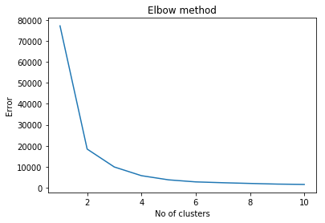

```python
Error =[] # this is the within-cluster sum of squares
for i in range(1, 11):
    kmeans = KMeans(n_clusters = i).fit(X)
    kmeans.fit(X)
    Error.append(kmeans.inertia_)
import matplotlib.pyplot as plt
plt.plot(range(1, 11), Error)
plt.title('Elbow method')
plt.xlabel('No of clusters')
plt.ylabel('Error')
plt.show()
```

**Analyze Results**

## Step 5: Create K-Means Clusters

```python
kmeans3 = KMeans(n_clusters=3) # 3 clusters
y_kmeans3 = kmeans3.fit_predict(X) # fit_predict returns back actual classes (in this case 0,1,2)
print(y_kmeans3)

kmeans3.cluster_centers_ # show what cluster each point is tied to
```

```
[2 1 0 1 1 1 2 0 1 1 2 1 0 1 2 0 0 2 2 1 2 0 2 1 1 0 1 1 2 2 0 1 0 0 2 0 0
 2 0 0 0 1 2 2 0 1 0 2 0 0 0 1 1 0 1 0 0 2 0 1 1 0 1 1 1 0 0 2 2 2 1 2 2 1
 2 0 0 2 0 1 2 0 2 0 0 0 0 2 0 0 2 0 1 0 2 2 0 1 2 0 2 2 1 0 1 1 0 0 1 1 0
 2 0 2 0 2 1 0 2 2 0 1 1 2 0 1 1 1 0 1 2 0 1 1 1 0 1 0 2 1 0 1 0 0 0 2 0 1
 0 0]
```

```
array([[   2.23132969,    2.39412568,    2.42150597,    2.40778689,
         212.1147541 ],
       [   2.20486111,    2.10503472,    2.42584746,    2.33940972,  181.75      ],
       [   1.94105691,    2.00711382,    2.11037619,    2.05284553,  161.        ]])
```

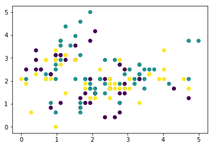

```python
plt.scatter(X[:,0],X[:,1], c=y_kmeans3)
```

NOTE: This is how a cluster graph could look like if it is two-dimensions (we are only using two columns in X for demo purposes), in reality the clusters are located within a 5-dimensional plot. The way to best view this is to create a **pairplot** which graphs every 2-dimensional set of features.

**Analyze Results**

- In this one graph, we do not have three distinct clusters
- Everything is jumbled up
- Let's create a pairplot to see how every 2-dimensional set of features interact

## Step 6: Generate Pairplot

```python
df['Class'] = np.array(y_kmeans3) # create class column
df.head()
```

[output not shown]

We use the identified clusters from Step 5 to create the Class column.

[figure not shown]

```python
sns.pairplot(df, hue = "Class")
```

**Analyze Results**

## Step 7: Re-Evaluate Data

```python
df.describe()
```

|  | Usability Rating | Safety Rating | Affordability Rating | General Rating | Height | Class |
| --- | --- | --- | --- | --- | --- | --- |
| count | 150.000000 | 150.000000 | 150.000000 | 150.000000 | 150.000000 | 150.000000 |
| mean | 2.143519 | 2.195833 | 2.337853 | 2.288889 | 188.426667 | 1.146667 |
| std | 1.150092 | 0.903321 | 1.495272 | 1.589918 | 22.600216 | 0.805907 |
| min | 0.000000 | 0.000000 | 0.000000 | 0.000000 | 150.000000 | 0.000000 |
| 25% | 1.111111 | 1.666667 | 0.508475 | 0.416667 | 170.000000 | 0.000000 |
| 50% | 2.083333 | 2.083333 | 2.838983 | 2.500000 | 185.000000 | 1.000000 |
| 75% | 2.916667 | 2.708333 | 3.474576 | 3.541667 | 207.000000 | 2.000000 |
| max | 5.000000 | 5.000000 | 5.000000 | 5.000000 | 229.000000 | 2.000000 |

**Analyze Results**

- The height column is on a significantly larger scale (150-229) than the other features (0-5)
- So, the K-means is factoring in the height column by far the most

Two ways to fix it:

- Scale the height column (if we believe height should be a feature)
- Remove the height column

In this case, I am going to remove the height column as it isn't a rating.

Let's see how things change after we do that.

## Step 8: Create New Feature Matrix (without Height)

```python
X = df.iloc[:, [0,1,2,3]].values
X
```

```
array([[ 1.11111111,  3.125     ,  0.33898305,  0.20833333],
       [ 0.83333333,  2.08333333,  0.33898305,  0.20833333],
       [ 0.55555556,  2.5       ,  0.25423729,  0.20833333],
       [ 0.41666667,  2.29166667,  0.42372881,  0.20833333],
       [ 0.97222222,  3.33333333,  0.33898305,  0.20833333],
       [ 1.52777778,  3.95833333,  0.59322034,  0.625     ],
       [ 0.41666667,  2.91666667,  0.33898305,  0.41666667],
       [ 0.97222222,  2.91666667,  0.42372881,  0.20833333],
       [ 0.13888889,  1.875     ,  0.33898305,  0.20833333],
       [ 0.83333333,  2.29166667,  0.42372881,  0.        ],
       [ 1.52777778,  3.54166667,  0.42372881,  0.20833333],
       [ 0.69444444,  2.91666667,  0.50847458,  0.20833333],
       [ 0.69444444,  2.08333333,  0.33898305,  0.        ],
       [ 0.        ,  2.08333333,  0.08474576,  0.        ],
       [ 2.08333333,  4.16666667,  0.16949153,  0.20833333],
       [ 1.94444444,  5.        ,  0.42372881,  0.625     ],
       [ 1.52777778,  3.95833333,  0.25423729,  0.625     ],
       [ 1.11111111,  3.125     ,  0.33898305,  0.41666667],
       [ 1.94444444,  3.75      ,  0.59322034,  0.41666667],
       [ 1.11111111,  3.75      ,  0.42372881,  0.41666667],
       [ 1.52777778,  2.91666667,  0.59322034,  0.20833333],
       [ 1.11111111,  3.54166667,  0.42372881,  0.625     ],
       [ 0.41666667,  3.33333333,  0.        ,  0.20833333],
       [ 1.11111111,  2.70833333,  0.59322034,  0.83333333],
       [ 0.69444444,  2.91666667,  0.76271186,  0.20833333],
       [ 0.97222222,  2.08333333,  0.50847458,  0.20833333],
       [ 0.97222222,  2.91666667,  0.50847458,  0.625     ],
       [ 1.25      ,  3.125     ,  0.42372881,  0.20833333],
       [ 1.25      ,  2.91666667,  0.33898305,  0.20833333],
       [ 0.55555556,  2.5       ,  0.50847458,  0.20833333],
       [ 0.69444444,  2.29166667,  0.50847458,  0.20833333],
       [ 1.52777778,  2.91666667,  0.42372881,  0.625     ],
       [ 1.25      ,  4.375     ,  0.42372881,  0.        ],
       [ 1.66666667,  4.58333333,  0.33898305,  0.20833333],
       [ 0.83333333,  2.29166667,  0.42372881,  0.        ],
       [ 0.97222222,  2.5       ,  0.16949153,  0.20833333],
       [ 1.66666667,  3.125     ,  0.25423729,  0.20833333],
       [ 0.83333333,  2.29166667,  0.42372881,  0.        ],
       [ 0.13888889,  2.08333333,  0.25423729,  0.20833333],
       [ 1.11111111,  2.91666667,  0.42372881,  0.20833333],
```

[output cut: 95 more lines]

```
       [ 4.72222222,  2.08333333,  4.3220339 ,  4.58333333],
       [ 2.77777778,  2.91666667,  3.89830508,  4.79166667],
       [ 2.91666667,  2.29166667,  3.81355932,  3.54166667],
       [ 2.36111111,  2.08333333,  3.22033898,  3.54166667],
       [ 3.61111111,  2.29166667,  3.72881356,  4.16666667],
       [ 3.33333333,  2.29166667,  3.89830508,  4.79166667],
       [ 3.61111111,  2.29166667,  3.47457627,  4.58333333],
       [ 2.08333333,  1.45833333,  3.47457627,  3.75      ],
       [ 3.47222222,  2.5       ,  4.15254237,  4.58333333],
       [ 3.33333333,  2.70833333,  3.98305085,  5.        ],
       [ 3.33333333,  2.08333333,  3.55932203,  4.58333333],
       [ 2.77777778,  1.04166667,  3.38983051,  3.75      ],
       [ 3.05555556,  2.08333333,  3.55932203,  3.95833333],
       [ 2.63888889,  2.91666667,  3.72881356,  4.58333333],
       [ 2.22222222,  2.08333333,  3.47457627,  3.54166667]])
```

## Step 9: Redo K-Means Clustering

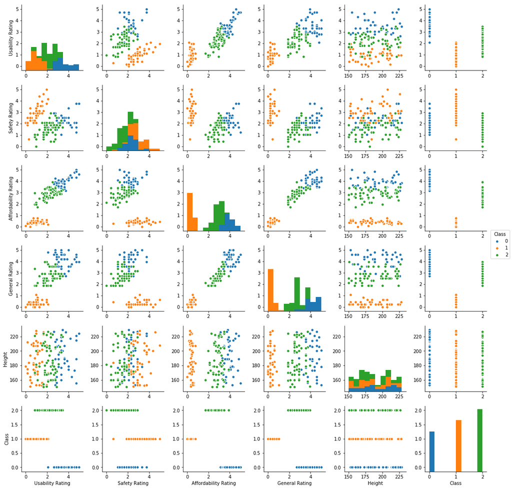

```python
kmeans3 = KMeans(n_clusters=3)
y_kmeans3 = kmeans3.fit_predict(X)
df['Class'] = np.array(y_kmeans3)
sns.pairplot(df, hue = "Class")
```

**Analyze Results**

- This looks much better!
- We now have three clearly defined clusters consistently
- We can classify these clusters by taking a look at the trends occurring in each graph
  - This is a completely subjective measure based on how you interpret the graphs
  - E.x. in Affordability vs. General Rating, how might we classify the orange, green, and blue clusters?
    - Orange: Low general ratings and low affordability ratings.
    - Green: Middling general ratings and middling affordability ratings.
    - Blue: High general ratings and high affordability ratings.
    - This might reflect users of three different income brackets, as the same scooter is seen as more or less affordable. It makes sense that ratings will be lower if someone considers it less affordable.

## Step 10: Hiearchical Clustering (Comparison)

Let's try hierarchical clustering as comparison. Recall that hierarchical clustering does not require us to define K clusters. However, note that the time-complexity of hierarchical clustering is $O(n^2)$ whereas K-means is $O(n)$, so it is more inefficient and is not always suitable for very large datasets. Fortunately, this dataset isn't too big!

The plot_dendogram function was taken from sklearn documentation.

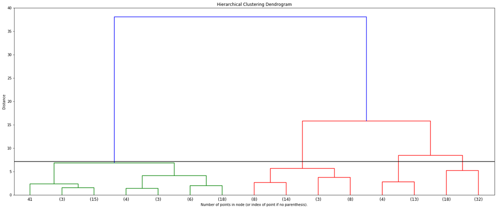

```python
from sklearn.cluster import AgglomerativeClustering
from scipy.cluster.hierarchy import dendrogram

def plot_dendrogram(model, **kwargs): # **kwargs refers to keyword arguments
    # Create linkage matrix and then plot the dendrogram

    # create the counts of samples under each node
    counts = np.zeros(model.children_.shape[0]) # the children refer to the branches of the model
    n_samples = len(model.labels_) # this how many samples there
    for i, merge in enumerate(model.children_):
        current_count = 0
        for child_idx in merge:
            if child_idx < n_samples:
                current_count += 1  # leaf node
            else:
                current_count += counts[child_idx - n_samples]
        counts[i] = current_count

    linkage_matrix = np.column_stack([model.children_, model.distances_,
                                      counts]).astype(float) # stack chidren, distances, and counts

    # Plot the corresponding dendrogram
    dendrogram(linkage_matrix, **kwargs)

# setting distance_threshold=0 ensures we compute the full tree.
model = AgglomerativeClustering(distance_threshold=0, n_clusters=None)

model = model.fit(X)
plt.figure(figsize=(25,10))
plt.title('Hierarchical Clustering Dendrogram')
# plot the top three levels of the dendrogram
plot_dendrogram(model, truncate_mode='level', p=3)
plt.xlabel("Number of points in node (or index of point if no parenthesis).")
plt.ylabel("Distance")
plt.axhline(y=7.1, c='k')
plt.show()
```

## Step 11: Split into Clusters

We can make any set of clustering based on how we cut the tree. Example below.

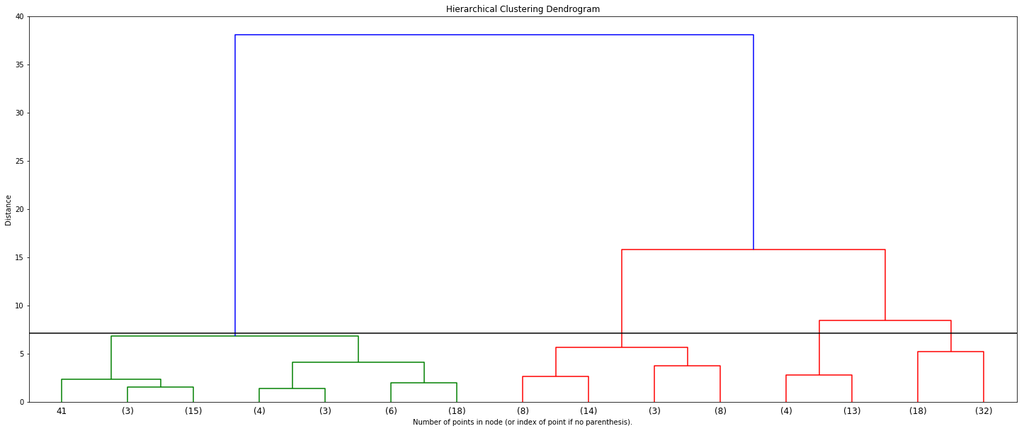

```python
from sklearn.cluster import AgglomerativeClustering
from scipy.cluster.hierarchy import dendrogram

def plot_dendrogram(model, **kwargs):
    # Create linkage matrix and then plot the dendrogram

    # create the counts of samples under each node
    counts = np.zeros(model.children_.shape[0]) # model.children_ refers to the child nodes
    n_samples = len(model.labels_) # we want to count the number of child nodes in each branch
    for i, merge in enumerate(model.children_):
        current_count = 0
        for child_idx in merge:
            if child_idx < n_samples:
                current_count += 1  # leaf node
            else:
                current_count += counts[child_idx - n_samples]
        counts[i] = current_count

    linkage_matrix = np.column_stack([model.children_, model.distances_,
                                      counts]).astype(float) # stack up the child nodes, the distances between the ndoes, and the node counts

    # Plot the corresponding dendrogram
    dendrogram(linkage_matrix, **kwargs)

# setting distance_threshold=0 ensures we compute the full tree.
model = AgglomerativeClustering(distance_threshold=0, n_clusters=None)

model = model.fit(X)
plt.figure(figsize=(25,10))
plt.title('Hierarchical Clustering Dendrogram')
# plot the top three levels of the dendrogram
plot_dendrogram(model, truncate_mode='level', p=3)
plt.xlabel("Number of points in node (or index of point if no parenthesis).")
plt.ylabel("Distance")
plt.axhline(y=7.1, c='k')
plt.show()
```

**Analyze Results**

- This gives us a total of 4 clusters, circled below

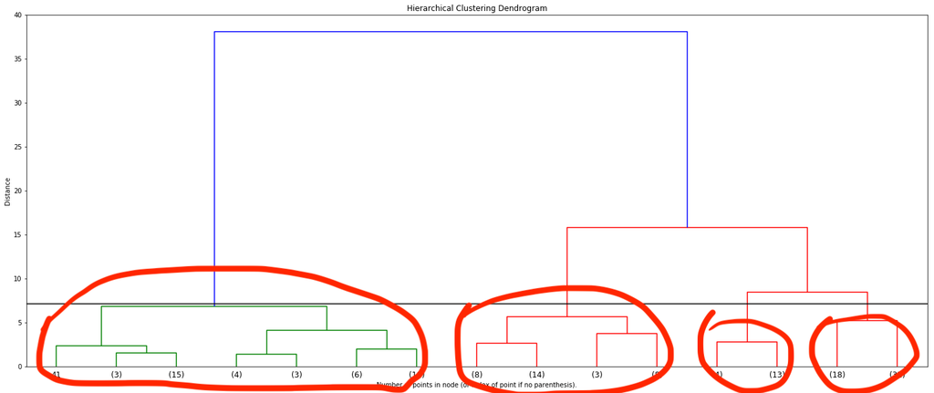

```python
from IPython.display import Image
Image("img/case_dendogram_clusters.png")
```

**Analyze Results**

- So how many clusters should we use? Should we just use 3 because the Elbow Curve said so?
  - While that is a good way to decide, technically there is no "right" answer to the number of clusters since it's just based on how you classify the clusters after

## Step 12: Summarize Client Deliverable

### K-Means Clustering

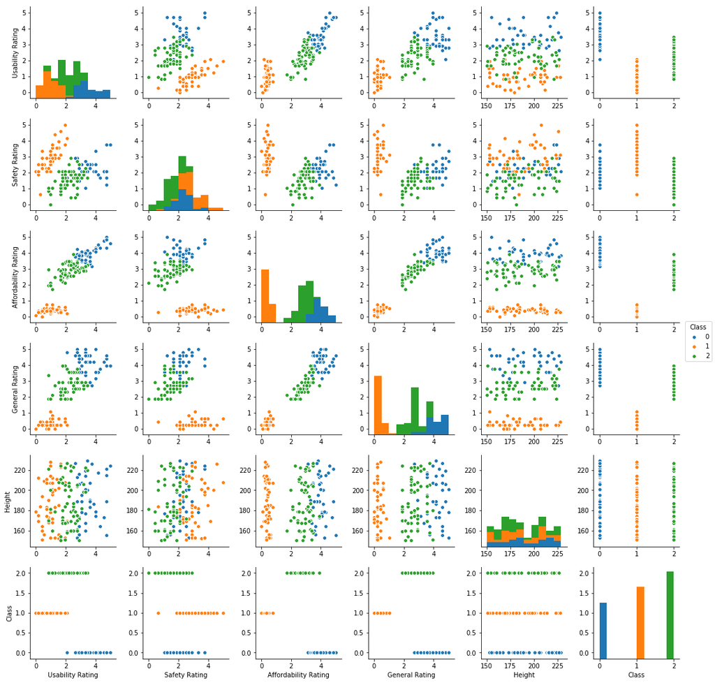

```python
import numpy as np
import pandas as pd
import matplotlib.pyplot as plt
from sklearn.cluster import KMeans
import seaborn as sns
%matplotlib inline
df = pd.read_csv("data/ratings.csv", index_col = 0)
X = df.iloc[:, [0,1,2,3]].values
kmeans3 = KMeans(n_clusters=3)
y_kmeans3 = kmeans3.fit_predict(X)
df['Class'] = np.array(y_kmeans3)
sns.pairplot(df, hue = "Class")
```

We can use the above to segment all customers into three main classes.

### Hierarchical Clustering

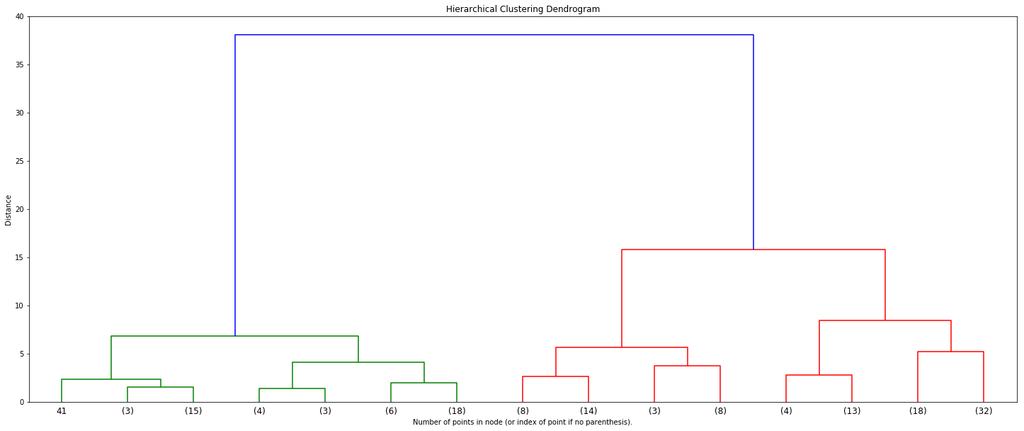

```python
import numpy as np
import pandas as pd
import matplotlib.pyplot as plt
from sklearn.cluster import AgglomerativeClustering
from scipy.cluster.hierarchy import dendrogram
%matplotlib inline

df = pd.read_csv("data/ratings.csv", index_col = 0)
X = df.iloc[:, [0,1,2,3]].values

def plot_dendrogram(model, **kwargs):
    # Create linkage matrix and then plot the dendrogram

    # create the counts of samples under each node
    counts = np.zeros(model.children_.shape[0]) # model.children_ refers to the child nodes
    n_samples = len(model.labels_) # we want to count the number of child nodes in each branch
    for i, merge in enumerate(model.children_):
        current_count = 0
        for child_idx in merge:
            if child_idx < n_samples:
                current_count += 1  # leaf node
            else:
                current_count += counts[child_idx - n_samples]
        counts[i] = current_count

    linkage_matrix = np.column_stack([model.children_, model.distances_,
                                      counts]).astype(float) # stack up the child nodes, the distances between the ndoes, and the node counts

    # Plot the corresponding dendrogram
    dendrogram(linkage_matrix, **kwargs)

# setting distance_threshold=0 ensures we compute the full tree.
model = AgglomerativeClustering(distance_threshold=0, n_clusters=None)

model = model.fit(X)
plt.figure(figsize=(25,10))
plt.title('Hierarchical Clustering Dendrogram')
# plot the top three levels of the dendrogram
plot_dendrogram(model, truncate_mode='level', p=3)
plt.xlabel("Number of points in node (or index of point if no parenthesis).")
plt.ylabel("Distance")
#plt.axhline(y=7.1, c='k')
plt.show()
```

The above can be cut in any way to make all possible clusterings.

## Conclusion

From a set of just features, we were able to generate clusters in an unsupervised way. Now, the client has interpretable data that can be used to segment out customers!